# Crustaceans case

### Trade quantity and price analysis, per region

Now we will zoom in to analyze trade quantity per region across time to uncover trends and map direction and magnitude of trade flows. In the following time charts we can see countries that have performed above the region’s average, marked with a black line. Next to these charts we will calculate the prices of imports and exports, by dividing the value of the trade in USD between the quantity of the trade in tonnes.

#### Africa

African trade surplus halted in 2009-2010 because of Nigerian exports, and shifted to deficit because Moroccan and Egyptian imports soared in 2010.

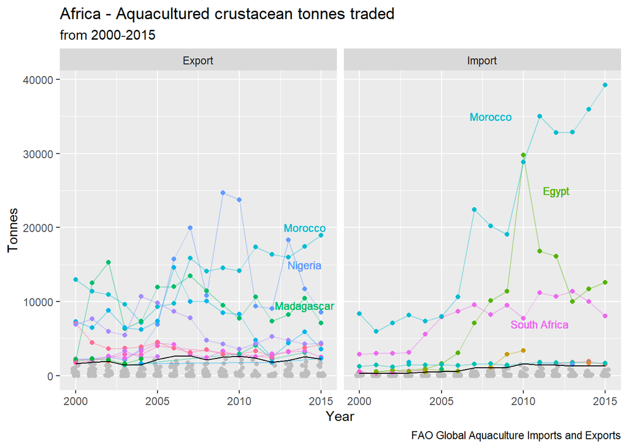

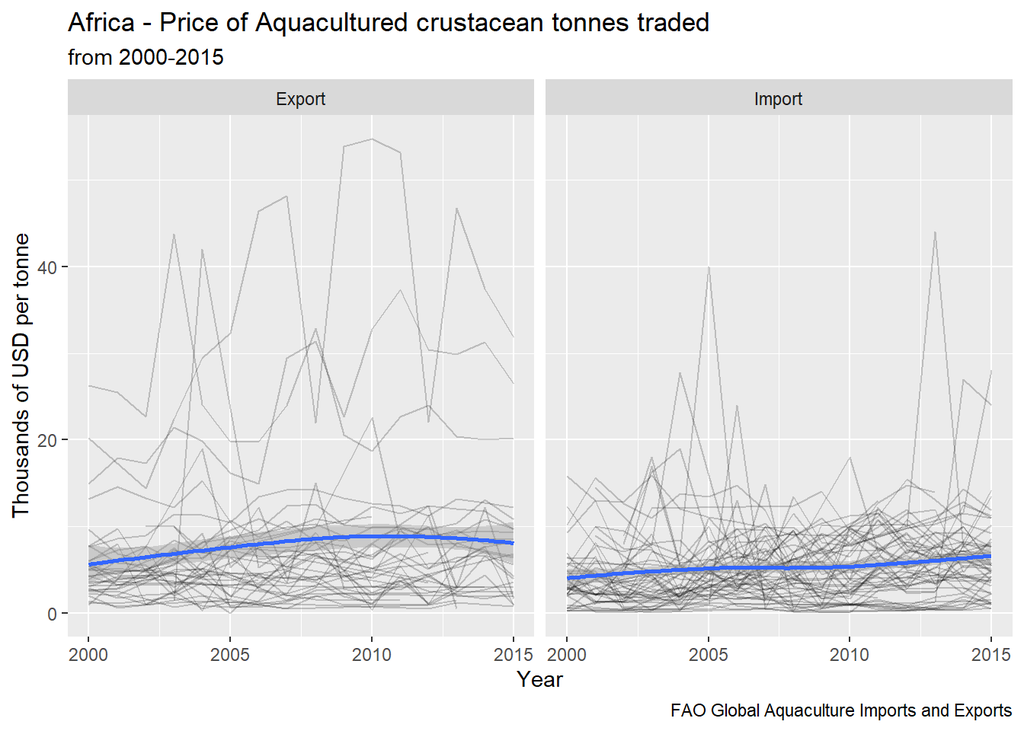

#### America

America shifted to trade surplus because its exports increased rapidly from 2011 onwards, likely because of Ecuador and other developing countries’ increase in exports in that same period.

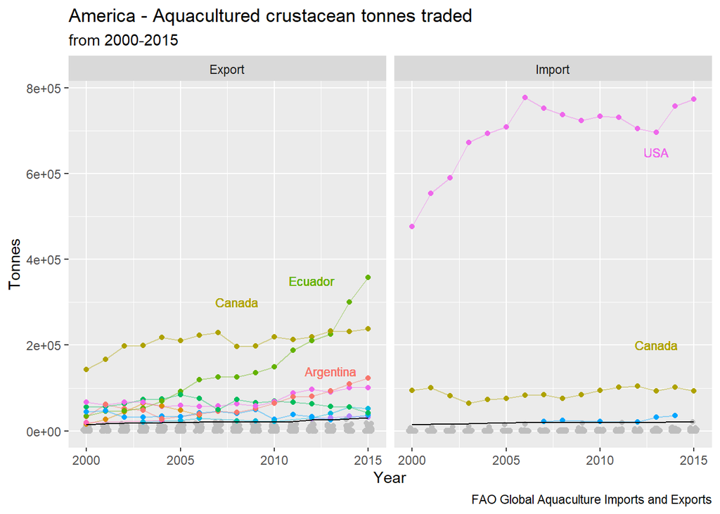

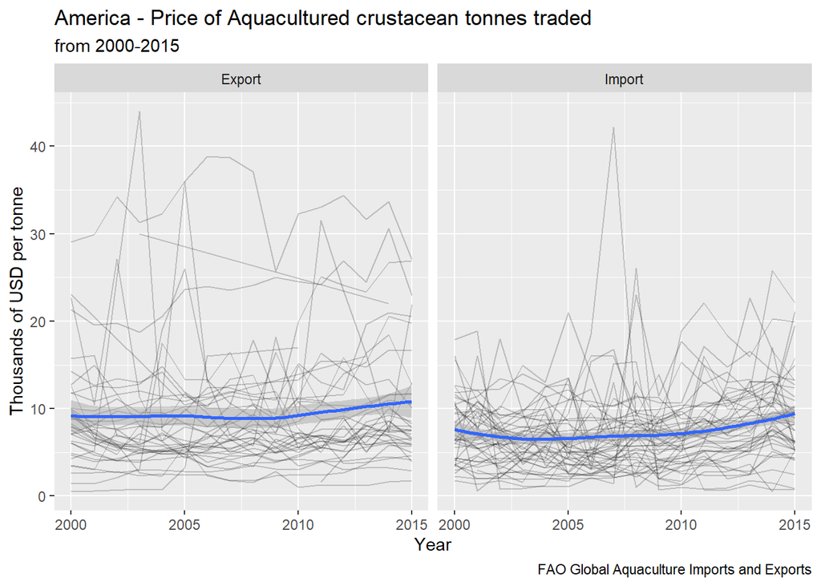

#### Asia

Asia can maintain such high trade surplus because it has 5 countries overperforming much above average.

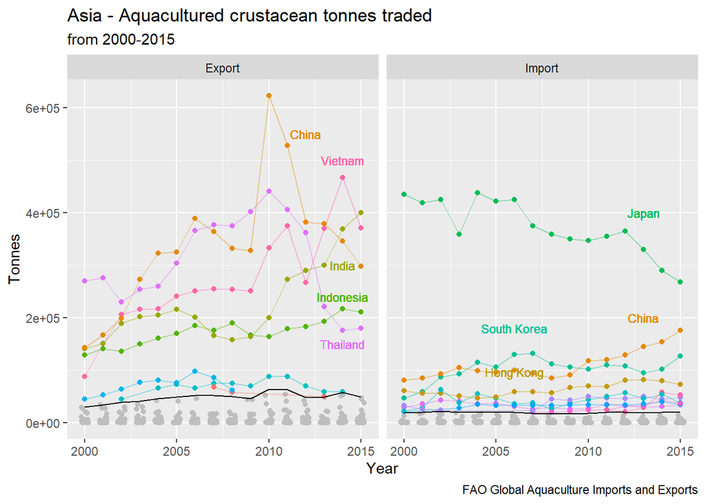

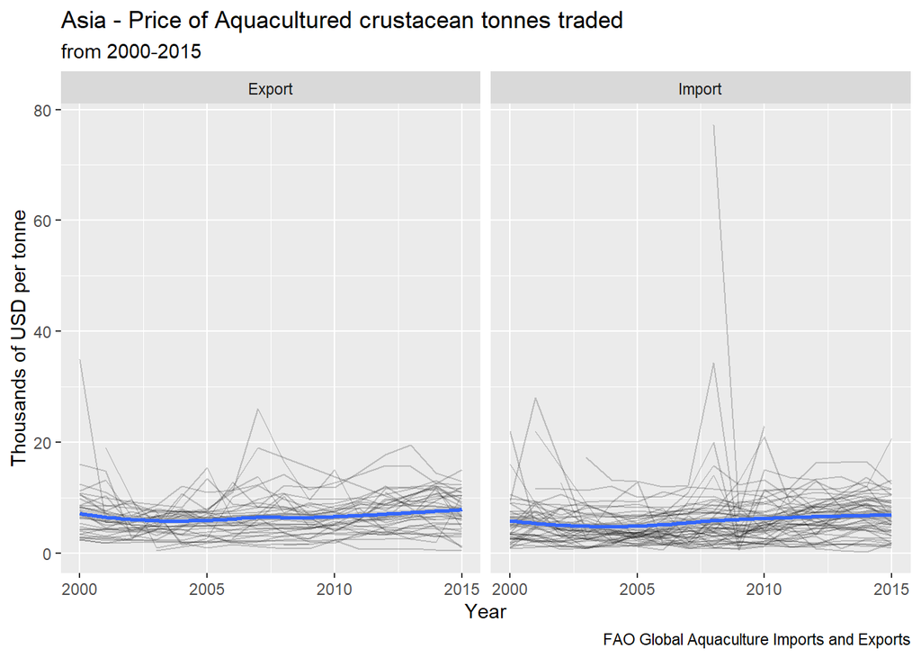

#### Europe

Europe does not hold such a wide trade deficit but it is still maintained, likely because it has more strong importers than exporters, and have remained stable in the examined period.

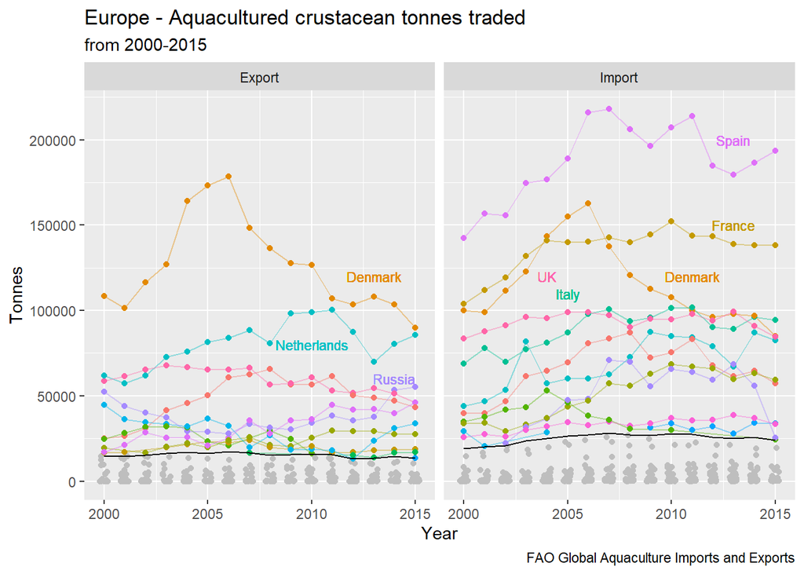

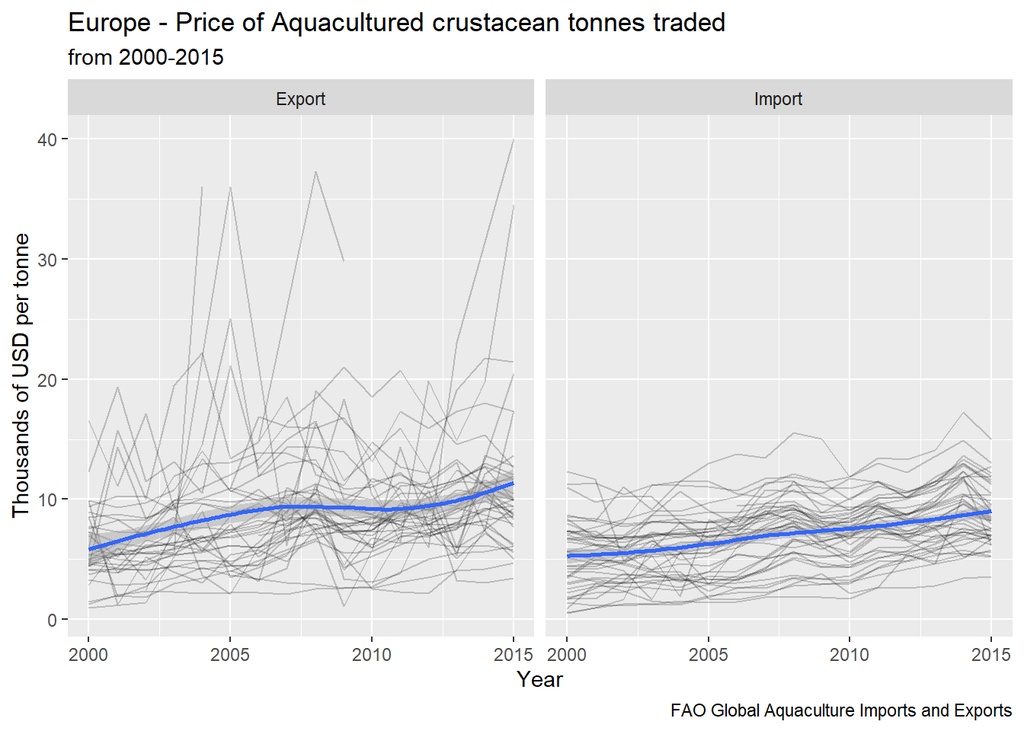

#### Oceania

Oceania’s shift from a surplus to a deficit is explained by Australia’s change from focusing on exports to imports in 2005.

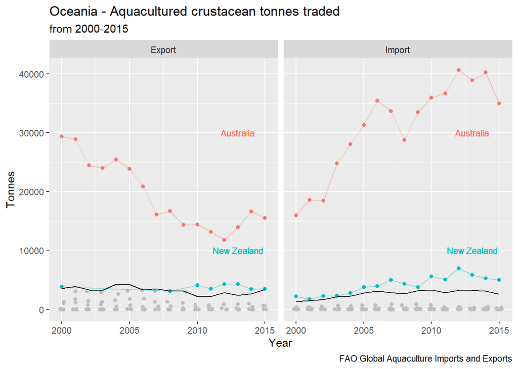

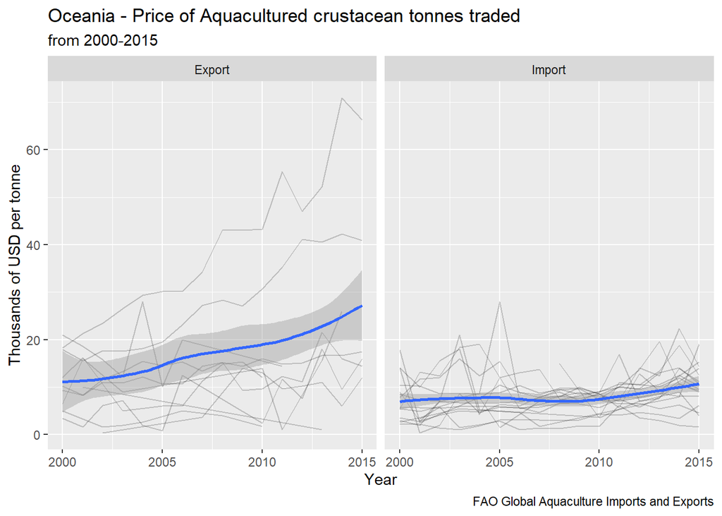

### Global values in context

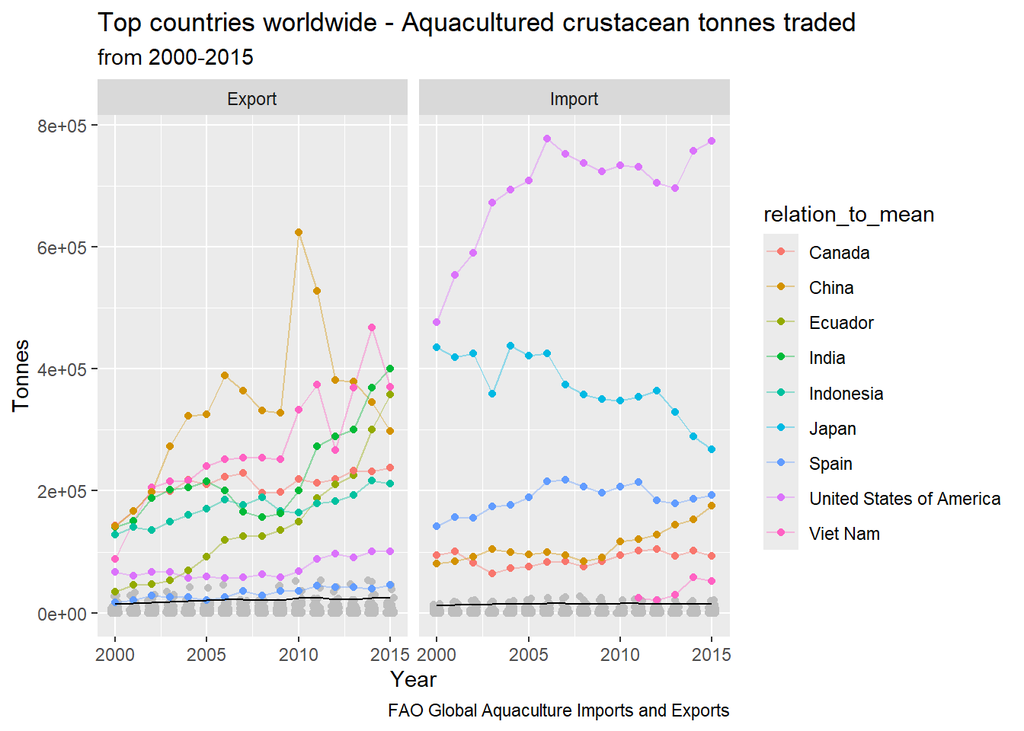

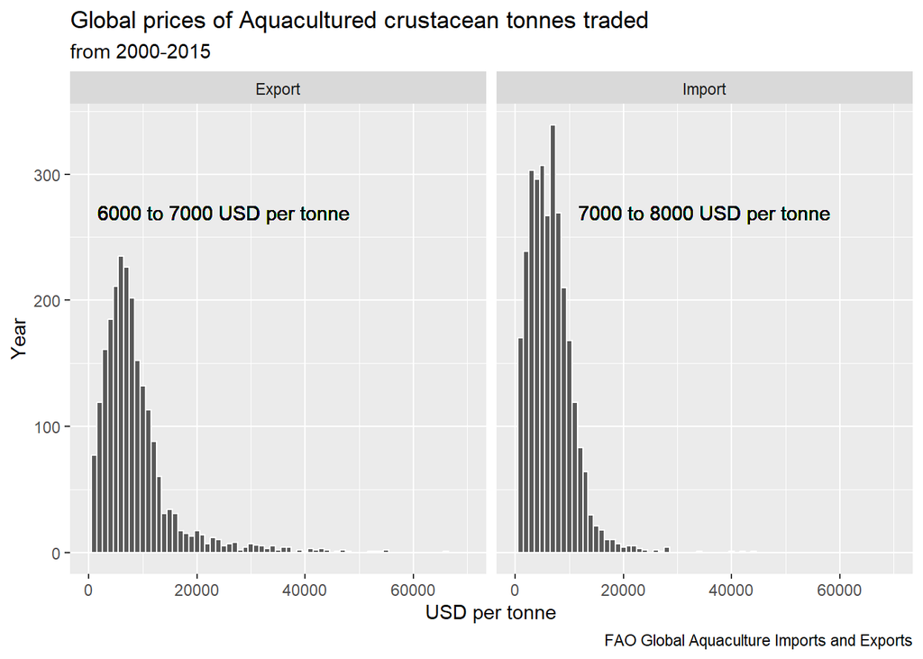

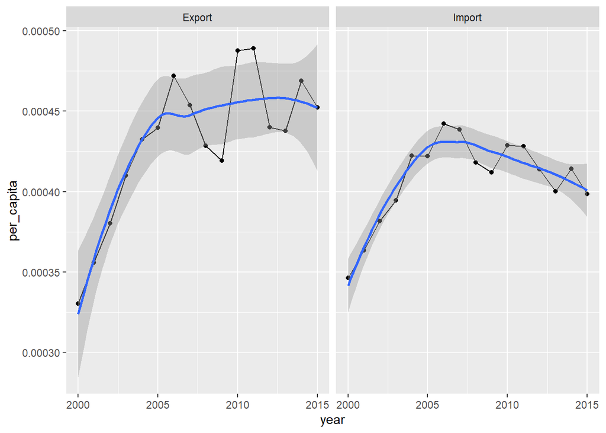

With these charts we can confirm the main movers per region for exports and imports, and how they behaved over the years.

## Findings

In this section we will discuss the main conclusions of the analysis, propose a solution to the business task and add a series of recommendations.

### Proposed solution outline

Having taken in all the previous data, in order to maximize the chances of success, the recommendation of the analyst is the following: Set up farms and operations in a country with active developing of aquaculture technology, where it can be easier found and applied across the industry. At the same time, located in a region where the biggest quantity of crustaceans will be commercialized. Therefore, we will be focusing on a region with both a country with high trade surplus and a country with high trade deficit. Only two regions meet this criteria: America and Asia. The analyst believes America is the safest bet because of the relatively low competition. Ecuador is the only country in the top 6 exporters in America, and a benchmark for innovation and technology transfer from the most competed industry in top Asian countries. At the same time, the US market is relatively close, enabling safer and cheaper exports than competitors in other regions.

#### Next steps

- Investigate trade policies in each of the proposed regions and countries.
- Investigate the state of aquaculture farm technology in each of the proposed regions and countries.
- Update the analyzed data for the next 10 year period, if available on the Food and Agriculture Organization of the United Nations (FAO) original reports (will need to scrape significantly).